# STAT5003

Week 7: Q & A

Dr. Justin Wishart

2020-10-14

> Examples given for MAR and MNAR seem to me like they are the same thing. What is the difference?
- Suppose the survey asked questions with the following variables

| Age | Salary | SES |
| --- | --- | --- |
| 16 | 100000 | 1 |
| NA | 100000 | 1 |
| 16 | 100 (NA) | 5 |
| 55 | 100000 | 1 |
| 55 | 1000000(NA) | 1 |

- Example 1: *E.g. Let’s say we run a survey and some people don’t want to give their age in the questionnaire, but this does not relate to any other variable (including their party preference)*
  - The age $(Y)$ is the variable with missing data. The missingness of age doesn’t depend on any other covariate. Some people just dont want to reveal their age. (Missing value of $Y$ doesn’t depend on anything) _ Verbally mentioned a missing completely at random survey style
    - There is another missing value technique to deal with this using available data
    - E.g. Can compute pairwise correlations to do a multiple regression model.
- Example 2: *In a survey, if people from a lower socioeconomic status may be less willing to provide salary information (but we know their SES status).*
  - The salary $(Y)$ is the variable with missing data. The missingness of salary depends on the SES variable.

> Some slides are missing images in the lecture PDF file. Is that an html exporting error? This occurs in previous weeks too.
- Yes it is. I was hoping to keep everything in HTML
  - Feedback welcome on how to fix this.

> Does this have to be random imputation?

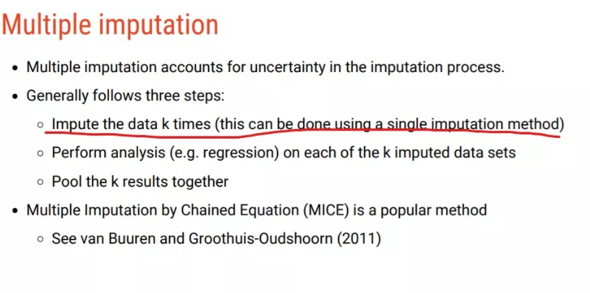

> Why is the meaning of: “the uncertainty in the missing value data is lost”?
- The comment there was referring to imputing missing data with a deterministic value.
- However, statistical methods try and model uncertainty in sampled values.
- Consider the extreme case.
- You believe population comes from bell curve
- Some are missing. You decide to replace the missing values with the mean.

> What is a dummy variable?

I think I may have used it in the lecture to describe that I was keeping track of which variable has been set to missing and which is not missing.

- Dummy variables are indicator or binary variables (either 0 or 1)
  - In the binary case, a zero would denote the variable doesn’t have the condition and 1 denotes the variable does have the condition.
  - E.g. in regression you might want to include information on gender (or age etc)
  - The model might be $Y = \beta_0 + \beta_1 X_1 + \beta_2X_2 + \varepsilon$

> Can you explain a little bit more the Cohen’s Kappa metric? Can you provide an example?

$$\kappa = \frac{p_o - p_e}{1 - p_e} = 1 - \frac{1 - p_o}{1 - p_e}$$

- $p_o =$ observed agreement of classes = Overall Accuracy
- $p_e =$ hypothetical expected agreement

Consider the simple case of binary classification (two classes) with $n$ cases Call the two judges, judges $A$ and $B$.

- Judge $A$ could denote the observed class assignment labels.
- Judge $B$ could denote the predicted class assignment labels

$$p_o = \text{Proportion of Agreement between judge $A$ and $B$} = \text{This is the accuracy.}$$

The other metric $p_e$ is the empirical chance these judges give the classification by chance.

$$\begin{align*}
p_e &= P(\text{Judge $A$ and Judge $B$ agree on a randomly picked element})\\
&= P(\text{Judge $A$ and Judge $B$ classify 1 or Judge $A$ and Judge $B$ classify 0})\\
&= P(\text{Judge $A$ and Judge $B$ classify 1}) + P(\text{Judge $A$ and Judge $B$ classify 0})\\
&= P(\text{Judge $A$ classify 1})P(\text{Judge $B$ classify 1}) + P(\text{Judge $A$ classify 0}) P(\text{Judge $B$ classify 0})
\end{align*}$$

```r
library(caret)
n <- 1e6; perc <- 98;
obs <- factor(rep(c(0, 1),  c(perc/100 * n, (100 - perc)/100 * n)))
m <- 0
pred <- factor(rep(c(0, 1), c(n - m, m)), levels = c(0, 1))
confusionMatrix(obs, pred)
```

```
## Confusion Matrix and Statistics
##
##           Reference
## Prediction      0      1
##          0 980000      0
##          1  20000      0
##
##                Accuracy : 0.98
##                  95% CI : (0.9797, 0.9803)
##     No Information Rate : 1
##     P-Value [Acc > NIR] : 1
##
##                   Kappa : 0
##
##  Mcnemar's Test P-Value : <2e-16
##
##             Sensitivity : 0.98
##             Specificity :   NA
##          Pos Pred Value :   NA
##          Neg Pred Value :   NA
##              Prevalence : 1.00
##          Detection Rate : 0.98
##    Detection Prevalence : 0.98
##       Balanced Accuracy :   NA
##
##        'Positive' Class : 0
##
```

```r
cM <- xtabs(~obs+pred)
cM
```

```
##    pred
## obs      0      1
##   0 980000      0
##   1  20000      0
```

Nice article on Cohen’s Kappa [here](https://thenewstack.io/cohens-kappa-what-it-is-when-to-use-it-and-how-to-avoid-its-pitfalls/)